# France

1. Cài đặt thư viện mlxtend và xlrd

Sau khi cài đặt, import các thư viện cần thiết: thư viện máy học (mlxtend)

```python
import pandas as pd
import seaborn as sns
import matplotlib.pyplot as plt
%matplotlib inline
from mlxtend.frequent_patterns import apriori
from mlxtend.frequent_patterns import association_rules
```

```python
with open('F:\DOWNLOAD\KHAI THAC DL\DATA\OR.csv') as f:
    df = pd.read_csv(f)
```

Sau khi dữ liệu được đọc vào biến df, hiển thị một vài thông tin của biến này

```python
df.info()
```

```
<class 'pandas.core.frame.DataFrame'>
RangeIndex: 541909 entries, 0 to 541908
Data columns (total 8 columns):
 #   Column       Non-Null Count   Dtype
---  ------       --------------   -----
 0   InvoiceNo    541909 non-null  object
 1   StockCode    541909 non-null  object
 2   Description  540455 non-null  object
 3   Quantity     541909 non-null  int64
 4   InvoiceDate  541909 non-null  object
 5   UnitPrice    541909 non-null  float64
 6   CustomerID   406829 non-null  float64
 7   Country      541909 non-null  object
dtypes: float64(2), int64(1), object(5)
memory usage: 33.1+ MB
```

1. Loại bỏ ký tự thừa ở tên mặt hàng mua (Description), xóa các dòng dữ liệu không có số hóa đơn (cột Invoice No) và chuyển nó về kiểu dữ liệu chuỗi.

```python
df['Description'] = df['Description'].str.strip()
df.dropna(axis=0, subset=['InvoiceNo'], inplace=True)
df['InvoiceNo'] = df['InvoiceNo'].astype('str')
```

Xem thử 10 dòng đầu của dữ liệu sau khi đã thực hiện thao tác làm sạch

```python
df.head(10)
```

|  | InvoiceNo | StockCode | Description | Quantity | InvoiceDate | UnitPrice | CustomerID | Country |
| --- | --- | --- | --- | --- | --- | --- | --- | --- |
| 0 | 536365 | 85123A | WHITE HANGING HEART T-LIGHT HOLDER | 6 | 12/1/2010 8:26 | 2.55 | 17850.0 | United Kingdom |
| 1 | 536365 | 71053 | WHITE METAL LANTERN | 6 | 12/1/2010 8:26 | 3.39 | 17850.0 | United Kingdom |
| 2 | 536365 | 84406B | CREAM CUPID HEARTS COAT HANGER | 8 | 12/1/2010 8:26 | 2.75 | 17850.0 | United Kingdom |
| 3 | 536365 | 84029G | KNITTED UNION FLAG HOT WATER BOTTLE | 6 | 12/1/2010 8:26 | 3.39 | 17850.0 | United Kingdom |
| 4 | 536365 | 84029E | RED WOOLLY HOTTIE WHITE HEART. | 6 | 12/1/2010 8:26 | 3.39 | 17850.0 | United Kingdom |
| 5 | 536365 | 22752 | SET 7 BABUSHKA NESTING BOXES | 2 | 12/1/2010 8:26 | 7.65 | 17850.0 | United Kingdom |
| 6 | 536365 | 21730 | GLASS STAR FROSTED T-LIGHT HOLDER | 6 | 12/1/2010 8:26 | 4.25 | 17850.0 | United Kingdom |
| 7 | 536366 | 22633 | HAND WARMER UNION JACK | 6 | 12/1/2010 8:28 | 1.85 | 17850.0 | United Kingdom |
| 8 | 536366 | 22632 | HAND WARMER RED POLKA DOT | 6 | 12/1/2010 8:28 | 1.85 | 17850.0 | United Kingdom |
| 9 | 536367 | 84879 | ASSORTED COLOUR BIRD ORNAMENT | 32 | 12/1/2010 8:34 | 1.69 | 13047.0 | United Kingdom |

Có thể xem một ví dụ về loại hóa đơn tín dụng bằng câu lệnh sau

```python
df[df.InvoiceNo.str.contains('C', na=False)].head()
```

|  | InvoiceNo | StockCode | Description | Quantity | InvoiceDate | UnitPrice | CustomerID | Country |
| --- | --- | --- | --- | --- | --- | --- | --- | --- |
| 141 | C536379 | D | Discount | -1 | 12/1/2010 9:41 | 27.50 | 14527.0 | United Kingdom |
| 154 | C536383 | 35004C | SET OF 3 COLOURED FLYING DUCKS | -1 | 12/1/2010 9:49 | 4.65 | 15311.0 | United Kingdom |
| 235 | C536391 | 22556 | PLASTERS IN TIN CIRCUS PARADE | -12 | 12/1/2010 10:24 | 1.65 | 17548.0 | United Kingdom |
| 236 | C536391 | 21984 | PACK OF 12 PINK PAISLEY TISSUES | -24 | 12/1/2010 10:24 | 0.29 | 17548.0 | United Kingdom |
| 237 | C536391 | 21983 | PACK OF 12 BLUE PAISLEY TISSUES | -24 | 12/1/2010 10:24 | 0.29 | 17548.0 | United Kingdom |

Tiến hành xóa những hóa đơn tín dụng

```python
df=df[~df['InvoiceNo'].str.contains('C')]
```

1. Thống kê dòng dữ liệu theo từng quốc gia

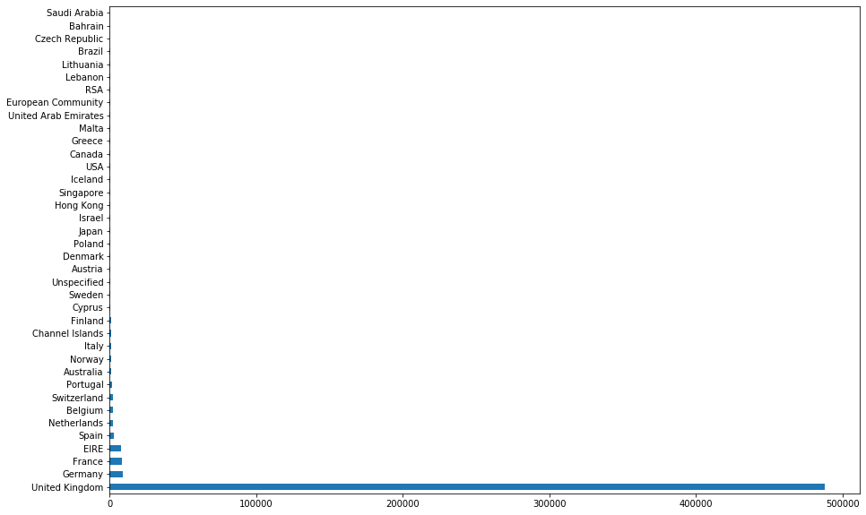

```python
df['Country'].value_counts().plot(kind='barh', figsize=(15,10))
```

Kết quả được hiển thị như hình trên.

1. Chỉ xét các hóa đơn từ nước Pháp và nhóm dữ liệu theo Số hóa đơn, Tên mặt hàng.

```python
basket = df[df['Country'] == "France"].groupby(['InvoiceNo', 'Description'])['Quantity']
```

1. Chuyển đổi dữ liệu về dạng hot encoding, với mỗi dòng dữ liệu là một hóa đơn

```python
basket = basket.sum().unstack().reset_index().fillna(0).set_index('InvoiceNo')
```

Xem dữ liệu sau khi chuyển về dạng hot encoding

```python
basket.head(10)
```

| Description InvoiceNo | 10 COLOUR SPACEBOY PEN | 12 COLOURED PARTY BALLOONS | 12 EGG HOUSE PAINTED WOOD | 12 MESSAGE CARDS WITH ENVELOPES | 12 PENCIL SMALL TUBE WOODLAND | 12 PENCILS SMALL TUBE RED RETROSPOT | 12 PENCILS SMALL TUBE SKULL | 12 PENCILS TALL TUBE POSY | 12 PENCILS TALL TUBE RED RETROSPOT | 12 PENCILS TALL TUBE WOODLAND | ... | WRAP VINTAGE PETALS DESIGN | YELLOW COAT RACK PARIS FASHION | YELLOW GIANT GARDEN THERMOMETER | YELLOW SHARK HELICOPTER | ZINC STAR T-LIGHT HOLDER | ZINC FOLKART SLEIGH BELLS | ZINC HERB GARDEN CONTAINER | ZINC METAL HEART DECORATION | ZINC T-LIGHT HOLDER STAR LARGE | ZINC T-LIGHT HOLDER STARS SMALL |
| --- | --- | --- | --- | --- | --- | --- | --- | --- | --- | --- | --- | --- | --- | --- | --- | --- | --- | --- | --- | --- | --- |
| 536370 | 0.0 | 0.0 | 0.0 | 0.0 | 0.0 | 0.0 | 0.0 | 0.0 | 0.0 | 0.0 | ... | 0.0 | 0.0 | 0.0 | 0.0 | 0.0 | 0.0 | 0.0 | 0.0 | 0.0 | 0.0 |
| 536852 | 0.0 | 0.0 | 0.0 | 0.0 | 0.0 | 0.0 | 0.0 | 0.0 | 0.0 | 0.0 | ... | 0.0 | 0.0 | 0.0 | 0.0 | 0.0 | 0.0 | 0.0 | 0.0 | 0.0 | 0.0 |
| 536974 | 0.0 | 0.0 | 0.0 | 0.0 | 0.0 | 0.0 | 0.0 | 0.0 | 0.0 | 0.0 | ... | 0.0 | 0.0 | 0.0 | 0.0 | 0.0 | 0.0 | 0.0 | 0.0 | 0.0 | 0.0 |
| 537065 | 0.0 | 0.0 | 0.0 | 0.0 | 0.0 | 0.0 | 0.0 | 0.0 | 0.0 | 0.0 | ... | 0.0 | 0.0 | 0.0 | 0.0 | 0.0 | 0.0 | 0.0 | 0.0 | 0.0 | 0.0 |
| 537463 | 0.0 | 0.0 | 0.0 | 0.0 | 0.0 | 0.0 | 0.0 | 0.0 | 0.0 | 0.0 | ... | 0.0 | 0.0 | 0.0 | 0.0 | 0.0 | 0.0 | 0.0 | 0.0 | 0.0 | 0.0 |
| 537468 | 24.0 | 0.0 | 0.0 | 0.0 | 0.0 | 0.0 | 0.0 | 0.0 | 0.0 | 0.0 | ... | 0.0 | 0.0 | 0.0 | 0.0 | 0.0 | 0.0 | 0.0 | 0.0 | 0.0 | 0.0 |
| 537693 | 0.0 | 0.0 | 0.0 | 0.0 | 0.0 | 0.0 | 0.0 | 0.0 | 0.0 | 0.0 | ... | 0.0 | 0.0 | 0.0 | 0.0 | 0.0 | 0.0 | 0.0 | 0.0 | 0.0 | 0.0 |
| 537897 | 0.0 | 0.0 | 0.0 | 0.0 | 0.0 | 0.0 | 0.0 | 0.0 | 0.0 | 0.0 | ... | 0.0 | 0.0 | 0.0 | 0.0 | 0.0 | 0.0 | 0.0 | 0.0 | 0.0 | 0.0 |
| 537967 | 0.0 | 0.0 | 0.0 | 0.0 | 0.0 | 0.0 | 0.0 | 0.0 | 0.0 | 0.0 | ... | 0.0 | 0.0 | 0.0 | 0.0 | 0.0 | 0.0 | 0.0 | 0.0 | 0.0 | 0.0 |
| 538008 | 0.0 | 0.0 | 0.0 | 0.0 | 0.0 | 0.0 | 0.0 | 0.0 | 0.0 | 0.0 | ... | 0.0 | 0.0 | 0.0 | 0.0 | 0.0 | 0.0 | 0.0 | 0.0 | 0.0 | 0.0 |

10 rows × 1563 columns

1. Tạo hàm biến đổi mỗi điểm dữ liệu có số lượng (Quantity) lớn hơn 0 thành 1

```python
def encode_data(datapoint):
    if datapoint <=0:
        return 0
    if datapoint >= 1:
        return 1
```

Chuyển đổi dữ liệu từ dạng hot encoding thành one-hot encoding

```python
basket = basket.applymap(encode_data)
```

1. Xóa cột 'POSTAGE'

```python
basket.drop('POSTAGE', inplace=True, axis=1)
```

1. Áp dụng thuật toán Apriori với min_sup = 7% để tìm tập phổ biến

```python
itemsets = apriori(basket, min_support=0.07, use_colnames=True)
```

Xem 10 phần tử đầu tiên trong tập phổ biến tìm được

```python
itemsets.head(10)
```

|  | support | itemsets |
| --- | --- | --- |
| 0 | 0.071429 | (4 TRADITIONAL SPINNING TOPS) |
| 1 | 0.096939 | (ALARM CLOCK BAKELIKE GREEN) |
| 2 | 0.102041 | (ALARM CLOCK BAKELIKE PINK) |
| 3 | 0.094388 | (ALARM CLOCK BAKELIKE RED) |
| 4 | 0.081633 | (BAKING SET 9 PIECE RETROSPOT) |
| 5 | 0.071429 | (CHILDRENS CUTLERY DOLLY GIRL) |
| 6 | 0.099490 | (DOLLY GIRL LUNCH BOX) |
| 7 | 0.096939 | (JUMBO BAG RED RETROSPOT) |
| 8 | 0.076531 | (JUMBO BAG WOODLAND ANIMALS) |
| 9 | 0.125000 | (LUNCH BAG APPLE DESIGN) |

1. Tạo luật kết hợp với min_conf = 70%

```python
rules = association_rules(itemsets, metric='confidence', min_threshold=0.7)
```

Xem thông tin về tập luật

```python
rules.info()
```

```
<class 'pandas.core.frame.DataFrame'>
RangeIndex: 20 entries, 0 to 19
Data columns (total 9 columns):
 #   Column              Non-Null Count  Dtype
---  ------              --------------  -----
 0   antecedents         20 non-null     object
 1   consequents         20 non-null     object
 2   antecedent support  20 non-null     float64
 3   consequent support  20 non-null     float64
 4   support             20 non-null     float64
 5   confidence          20 non-null     float64
 6   lift                20 non-null     float64
 7   leverage            20 non-null     float64
 8   conviction          20 non-null     float64
dtypes: float64(7), object(2)
memory usage: 1.5+ KB
```

Chuyển đổi vế trái và vế phải từ kiểu object (frozenset) về kiểu chuỗi (unicode)

```python
rules["antecedents"] = rules["antecedents"].apply(lambda x: list(x)[0]).astype("unicode")
rules["consequents"] = rules["consequents"].apply(lambda x: list(x)[0]).astype("unicode")
```

Viết lệnh in ra các luật đã tìm được

```python
for i in range(len(rules)):
    print(rules.loc[i, 'antecedents'],' ==> ', rules.loc[i, 'consequents'],
         ' [', rules.loc[i, 'support'], ', ', rules.loc[i, 'confidence'], ']')
```

```
ALARM CLOCK BAKELIKE PINK  ==>  ALARM CLOCK BAKELIKE GREEN  [ 0.07397959183673469 ,  0.725 ]
ALARM CLOCK BAKELIKE GREEN  ==>  ALARM CLOCK BAKELIKE PINK  [ 0.07397959183673469 ,  0.7631578947368421 ]
ALARM CLOCK BAKELIKE GREEN  ==>  ALARM CLOCK BAKELIKE RED  [ 0.07908163265306123 ,  0.8157894736842106 ]
ALARM CLOCK BAKELIKE RED  ==>  ALARM CLOCK BAKELIKE GREEN  [ 0.07908163265306123 ,  0.8378378378378379 ]
ALARM CLOCK BAKELIKE PINK  ==>  ALARM CLOCK BAKELIKE RED  [ 0.07397959183673469 ,  0.725 ]
ALARM CLOCK BAKELIKE RED  ==>  ALARM CLOCK BAKELIKE PINK  [ 0.07397959183673469 ,  0.7837837837837838 ]
DOLLY GIRL LUNCH BOX  ==>  SPACEBOY LUNCH BOX  [ 0.07142857142857142 ,  0.717948717948718 ]
PLASTERS IN TIN SPACEBOY  ==>  PLASTERS IN TIN WOODLAND ANIMALS  [ 0.10459183673469388 ,  0.7592592592592594 ]
SET/6 RED SPOTTY PAPER CUPS  ==>  SET/20 RED RETROSPOT PAPER NAPKINS  [ 0.10204081632653061 ,  0.7407407407407408 ]
SET/20 RED RETROSPOT PAPER NAPKINS  ==>  SET/6 RED SPOTTY PAPER CUPS  [ 0.10204081632653061 ,  0.7692307692307692 ]
SET/20 RED RETROSPOT PAPER NAPKINS  ==>  SET/6 RED SPOTTY PAPER PLATES  [ 0.10204081632653061 ,  0.7692307692307692 ]
SET/6 RED SPOTTY PAPER PLATES  ==>  SET/20 RED RETROSPOT PAPER NAPKINS  [ 0.10204081632653061 ,  0.8 ]
SET/6 RED SPOTTY PAPER CUPS  ==>  SET/6 RED SPOTTY PAPER PLATES  [ 0.12244897959183673 ,  0.888888888888889 ]
SET/6 RED SPOTTY PAPER PLATES  ==>  SET/6 RED SPOTTY PAPER CUPS  [ 0.12244897959183673 ,  0.96 ]
SET/6 RED SPOTTY PAPER CUPS  ==>  SET/6 RED SPOTTY PAPER PLATES  [ 0.09948979591836735 ,  0.975 ]
SET/6 RED SPOTTY PAPER CUPS  ==>  SET/20 RED RETROSPOT PAPER NAPKINS  [ 0.09948979591836735 ,  0.8125 ]
SET/6 RED SPOTTY PAPER PLATES  ==>  SET/6 RED SPOTTY PAPER CUPS  [ 0.09948979591836735 ,  0.975 ]
SET/6 RED SPOTTY PAPER CUPS  ==>  SET/6 RED SPOTTY PAPER PLATES  [ 0.09948979591836735 ,  0.7222222222222223 ]
SET/20 RED RETROSPOT PAPER NAPKINS  ==>  SET/6 RED SPOTTY PAPER CUPS  [ 0.09948979591836735 ,  0.75 ]
SET/6 RED SPOTTY PAPER PLATES  ==>  SET/6 RED SPOTTY PAPER CUPS  [ 0.09948979591836735 ,  0.78 ]
```

1. Lấy gía trị độ hỗ trợ và độ tin cậy của tập luật

```python
support=rules['support'].values
confidence=rules['confidence'].values
```

Biểu diễn các thông tin này lên biểu đồ

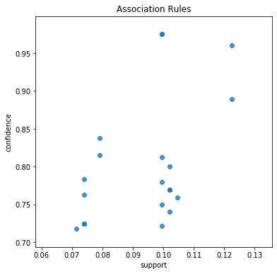

```python
plt.figure(figsize=(6, 6))
plt.title('Association Rules')
plt.xlabel('support')
plt.ylabel('confidence')
sns.regplot(x=support, y=confidence, fit_reg=False)
```

1. Import module fpgrowth từ thư viện mlxtend và tìm tập phổ biến bằng thuật toán FP-Growth

```python
from mlxtend.frequent_patterns import fpgrowth
itemsets = fpgrowth(basket, min_support=0.05, use_colnames=True)
```

Xem 10 phần tử đầu tiên trong tập phổ biến tìm được

```python
itemsets.head(10)
```

|  | support | itemsets |
| --- | --- | --- |
| 0 | 0.181122 | (RED TOADSTOOL LED NIGHT LIGHT) |
| 1 | 0.158163 | (ROUND SNACK BOXES SET OF4 WOODLAND) |
| 2 | 0.125000 | (SPACEBOY LUNCH BOX) |
| 3 | 0.104592 | (MINI PAINT SET VINTAGE) |
| 4 | 0.102041 | (ALARM CLOCK BAKELIKE PINK) |
| 5 | 0.096939 | (ALARM CLOCK BAKELIKE GREEN) |
| 6 | 0.094388 | (ALARM CLOCK BAKELIKE RED) |
| 7 | 0.068878 | (CIRCUS PARADE LUNCH BOX) |
| 8 | 0.068878 | (LUNCH BOX I LOVE LONDON) |
| 9 | 0.066327 | (CHARLOTTE BAG DOLLY GIRL DESIGN) |

1. Tạo luật kết hợp với min_conf = 70%

```python
rules = association_rules(itemsets, metric='confidence', min_threshold=0.7)
```

Xem thông tin về tập luật

```python
rules.info()
```

```
<class 'pandas.core.frame.DataFrame'>
RangeIndex: 29 entries, 0 to 28
Data columns (total 9 columns):
 #   Column              Non-Null Count  Dtype
---  ------              --------------  -----
 0   antecedents         29 non-null     object
 1   consequents         29 non-null     object
 2   antecedent support  29 non-null     float64
 3   consequent support  29 non-null     float64
 4   support             29 non-null     float64
 5   confidence          29 non-null     float64
 6   lift                29 non-null     float64
 7   leverage            29 non-null     float64
 8   conviction          29 non-null     float64
dtypes: float64(7), object(2)
memory usage: 2.2+ KB
```

Chuyển đổi vế trái và vế phải từ kiểu object (frozenset) về kiểu chuỗi (unicode)

```python
rules["antecedents"] = rules["antecedents"].apply(lambda x: list(x)[0]).astype("unicode")
rules["consequents"] = rules["consequents"].apply(lambda x: list(x)[0]).astype("unicode")
```

Viết lệnh in ra các luật đã tìm được

```python
for i in range(len(rules)):
    print(rules.loc[i, 'antecedents'],' ==> ', rules.loc[i, 'consequents'],
         ' [', rules.loc[i, 'support'], ', ', rules.loc[i, 'confidence'], ']')
```

```
ALARM CLOCK BAKELIKE PINK  ==>  ALARM CLOCK BAKELIKE GREEN  [ 0.07397959183673469 ,  0.725 ]
ALARM CLOCK BAKELIKE GREEN  ==>  ALARM CLOCK BAKELIKE PINK  [ 0.07397959183673469 ,  0.7631578947368421 ]
ALARM CLOCK BAKELIKE GREEN  ==>  ALARM CLOCK BAKELIKE RED  [ 0.07908163265306123 ,  0.8157894736842106 ]
ALARM CLOCK BAKELIKE RED  ==>  ALARM CLOCK BAKELIKE GREEN  [ 0.07908163265306123 ,  0.8378378378378379 ]
ALARM CLOCK BAKELIKE PINK  ==>  ALARM CLOCK BAKELIKE RED  [ 0.07397959183673469 ,  0.725 ]
ALARM CLOCK BAKELIKE RED  ==>  ALARM CLOCK BAKELIKE PINK  [ 0.07397959183673469 ,  0.7837837837837838 ]
ALARM CLOCK BAKELIKE PINK  ==>  ALARM CLOCK BAKELIKE RED  [ 0.06377551020408163 ,  0.8620689655172414 ]
ALARM CLOCK BAKELIKE RED  ==>  ALARM CLOCK BAKELIKE PINK  [ 0.06377551020408163 ,  0.8064516129032258 ]
ALARM CLOCK BAKELIKE PINK  ==>  ALARM CLOCK BAKELIKE GREEN  [ 0.06377551020408163 ,  0.8620689655172414 ]
PLASTERS IN TIN SPACEBOY  ==>  PLASTERS IN TIN WOODLAND ANIMALS  [ 0.10459183673469388 ,  0.7592592592592594 ]
PLASTERS IN TIN CIRCUS PARADE  ==>  PLASTERS IN TIN WOODLAND ANIMALS  [ 0.06887755102040816 ,  0.7714285714285714 ]
SET/6 RED SPOTTY PAPER CUPS  ==>  SET/6 RED SPOTTY PAPER PLATES  [ 0.12244897959183673 ,  0.888888888888889 ]
SET/6 RED SPOTTY PAPER PLATES  ==>  SET/6 RED SPOTTY PAPER CUPS  [ 0.12244897959183673 ,  0.96 ]
SET/20 RED RETROSPOT PAPER NAPKINS  ==>  SET/6 RED SPOTTY PAPER PLATES  [ 0.10204081632653061 ,  0.7692307692307692 ]
SET/6 RED SPOTTY PAPER PLATES  ==>  SET/20 RED RETROSPOT PAPER NAPKINS  [ 0.10204081632653061 ,  0.8 ]
SET/6 RED SPOTTY PAPER CUPS  ==>  SET/6 RED SPOTTY PAPER PLATES  [ 0.09948979591836735 ,  0.975 ]
SET/6 RED SPOTTY PAPER CUPS  ==>  SET/20 RED RETROSPOT PAPER NAPKINS  [ 0.09948979591836735 ,  0.8125 ]
SET/6 RED SPOTTY PAPER PLATES  ==>  SET/6 RED SPOTTY PAPER CUPS  [ 0.09948979591836735 ,  0.975 ]
SET/6 RED SPOTTY PAPER CUPS  ==>  SET/6 RED SPOTTY PAPER PLATES  [ 0.09948979591836735 ,  0.7222222222222223 ]
SET/20 RED RETROSPOT PAPER NAPKINS  ==>  SET/6 RED SPOTTY PAPER CUPS  [ 0.09948979591836735 ,  0.75 ]
SET/6 RED SPOTTY PAPER PLATES  ==>  SET/6 RED SPOTTY PAPER CUPS  [ 0.09948979591836735 ,  0.78 ]
DOLLY GIRL LUNCH BOX  ==>  SPACEBOY LUNCH BOX  [ 0.07142857142857142 ,  0.717948717948718 ]
SET/6 RED SPOTTY PAPER CUPS  ==>  SET/20 RED RETROSPOT PAPER NAPKINS  [ 0.10204081632653061 ,  0.7407407407407408 ]
SET/20 RED RETROSPOT PAPER NAPKINS  ==>  SET/6 RED SPOTTY PAPER CUPS  [ 0.10204081632653061 ,  0.7692307692307692 ]
PLASTERS IN TIN STRONGMAN  ==>  PLASTERS IN TIN CIRCUS PARADE  [ 0.058673469387755105 ,  0.7187500000000001 ]
PACK OF 6 SKULL PAPER CUPS  ==>  PACK OF 6 SKULL PAPER PLATES  [ 0.05102040816326531 ,  0.8 ]
PACK OF 6 SKULL PAPER PLATES  ==>  PACK OF 6 SKULL PAPER CUPS  [ 0.05102040816326531 ,  0.9090909090909091 ]
CHILDRENS CUTLERY DOLLY GIRL  ==>  CHILDRENS CUTLERY SPACEBOY  [ 0.06377551020408163 ,  0.8928571428571429 ]
CHILDRENS CUTLERY SPACEBOY  ==>  CHILDRENS CUTLERY DOLLY GIRL  [ 0.06377551020408163 ,  0.925925925925926 ]
```

1. Lấy gía trị độ hỗ trợ và độ tin cậy của tập luật

```python
support=rules['support'].values
confidence=rules['confidence'].values
```

Biểu diễn thông tin này lên biểu đồ

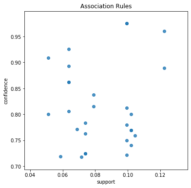

```python
plt.figure(figsize=(6, 6))
plt.title('Association Rules')
plt.xlabel('support')
plt.ylabel('confidence')
sns.regplot(x=support, y=confidence, fit_reg=False)
```

Kết quả thu được hình trên